# Final Project Proposal

Author

Giovanni Lunetta & Sam Lutzel

```r
library(tidyverse)
library(tidymodels)
library(dplyr)
library(stringr)
library(tidyr)
library(ggplot2)
```

# Data Import

```r
# read in data
playoffs_2002_2020 <- read_csv("/Users/giovanni-lunetta/uconn_masters/s2/stat_5125/Final Project/playoffs_2002_2020.csv")
```

```
──────────────────────────────────────────────────────── Delimiter: "," chr
(11): source, Round, Day, Date, ...7, Favorite(Seed), Score, Spread, ..... dbl
(1): ...1 time (1): Time (ET)
```

```r
playoffs_2021_2023 <- read_csv("/Users/giovanni-lunetta/uconn_masters/s2/stat_5125/Final Project/playoffs_2021_2023.csv")
```

```
──────────────────────────────────────────────────────── Delimiter: "," chr
(11): source, Round, Day, Date, ...7, Favorite(Seed), Score, Spread, ..... dbl
(1): ...1 time (1): Time (ET)
```

```r
regular_season_2002_2020 <- read_csv("/Users/giovanni-lunetta/uconn_masters/s2/stat_5125/Final Project/regular_season_2002_2020.csv")
```

```
──────────────────────────────────────────────────────── Delimiter: "," chr
(12): source, Day, Date, ...6, Favorite, Score, Spread, ...10, Underdog... dbl
(1): ...1 time (1): Time (ET)
```

```r
regular_season_2021_2023 <- read_csv("/Users/giovanni-lunetta/uconn_masters/s2/stat_5125/Final Project/regular_season_2021_2023.csv")
```

```
──────────────────────────────────────────────────────── Delimiter: "," chr
(11): source, Day, Date, ...6, Favorite, Score, Spread, ...10, Underdog... dbl
(1): ...1 lgl (1): ...14 time (1): Time (ET)
```

```r
playoffs_2002_2020 |>
    glimpse()
```

```
Rows: 211
Columns: 13
$ ...1             <dbl> 1, 2, 3, 4, 5, 6, 7, 8, 9, 10, 11, 12, 13, 14, 15, 16…
$ source           <chr> "Year_2002_Playoffs", "Year_2002_Playoffs", "Year_200…
$ Round            <chr> "AFC Wild Card", "NFC Wild Card", "AFC Wild Card", "N…
$ Day              <chr> "Sat", "Sat", "Sun", "Sun", "Sat", "Sat", "Sun", "Sun…
$ Date             <chr> "Jan 4, 2003", "Jan 4, 2003", "Jan 5, 2003", "Jan 5, …
$ `Time (ET)`      <time> 04:39:00, 08:08:00, 01:01:00, 04:47:00, 04:36:00, 08…
$ ...7             <chr> "@", "@", "@", "@", "@", "@", "@", "@", "@", "@", "N"…
$ `Favorite(Seed)` <chr> "New York Jets (4)", "Green Bay Packers (3)", "Pittsb…
$ Score            <chr> "W 41-0", "L 7-27", "W 36-33", "W 39-38", "W 34-31 (O…
$ Spread           <chr> "W -6", "L -6.5", "L -8", "L -3", "L -4.5", "W -7.5",…
$ ...11            <chr> NA, NA, NA, NA, NA, NA, NA, NA, NA, NA, NA, "@", NA, …
$ `Underdog(Seed)` <chr> "Indianapolis Colts (5)", "Atlanta Falcons (6)", "Cle…
$ `Over/Under`     <chr> "U 42", "U 40.5", "O 41", "O 41", "O 44", "U 38.5", "…
```

```r
playoffs_2021_2023 |>
    glimpse()
```

```
Rows: 39
Columns: 13
$ ...1             <dbl> 1, 2, 3, 4, 5, 6, 7, 8, 9, 10, 11, 12, 13, 14, 15, 16…
$ source           <chr> "Year_2021_Playoffs", "Year_2021_Playoffs", "Year_202…
$ Round            <chr> "AFC Wild Card", "AFC Wild Card", "NFC Wild Card", "N…
$ Day              <chr> "Sat", "Sat", "Sun", "Sun", "Sun", "Mon", "Sat", "Sat…
$ Date             <chr> "Jan 15, 2022", "Jan 15, 2022", "Jan 16, 2022", "Jan …
$ `Time (ET)`      <time> 04:30:00, 08:15:00, 01:00:00, 04:40:00, 08:15:00, 08…
$ ...7             <chr> "@", "@", "@", "@", "@", "@", "@", "@", "@", "@", "@"…
$ `Favorite(Seed)` <chr> "Cincinnati Bengals (4)", "Buffalo Bills (3)", "Tampa…
$ Score            <chr> "W 26-19", "W 47-17", "W 31-15", "L 17-23", "W 42-21"…
$ Spread           <chr> "W -5.5", "W -4", "W -8.5", "L -3", "W -12.5", "W -3.…
$ ...11            <chr> NA, NA, NA, NA, NA, NA, NA, NA, NA, NA, NA, NA, NA, N…
$ `Underdog(Seed)` <chr> "Las Vegas Raiders (5)", "New England Patriots (6)", …
$ `Over/Under`     <chr> "U 49", "O 44", "O 45.5", "U 51", "O 46.5", "U 49.5",…
```

```r
regular_season_2002_2020 |>
    glimpse()
```

```
Rows: 4,864
Columns: 14
$ ...1         <dbl> 1, 2, 3, 4, 5, 6, 7, 8, 9, 10, 11, 12, 13, 14, 15, 16, 17…
$ source       <chr> "Year_2002_Week_1", "Year_2002_Week_1", "Year_2002_Week_1…
$ Day          <chr> "Thu", "Sun", "Sun", "Sun", "Sun", "Sun", "Sun", "Sun", "…
$ Date         <chr> "Sep 5, 2002", "Sep 8, 2002", "Sep 8, 2002", "Sep 8, 2002…
$ `Time (ET)`  <time> 08:38:00, 01:04:00, 01:04:00, 01:04:00, 01:04:00, 01:04:…
$ ...6         <chr> NA, NA, "@", "@", "@", "@", "@", NA, "@", "@", "@", "@", …
$ Favorite     <chr> "San Francisco 49ers", "New York Jets", "Carolina Panther…
$ Score        <chr> "W 16-13", "W 37-31 (OT)", "W 10-7", "W 27-23", "L 6-34",…
$ Spread       <chr> "L -4", "W -3", "W PK", "L -4.5", "L -3", "L -2", "L -7",…
$ ...10        <chr> "@", "@", NA, NA, NA, NA, NA, "@", NA, NA, NA, NA, "@", N…
$ Underdog     <chr> "New York Giants", "Buffalo Bills", "Baltimore Ravens", "…
$ `Over/Under` <chr> "U 39", "O 43", "U 33", "O 41", "O 37", "O 36", "O 42.5",…
$ Notes        <chr> "Notes", NA, NA, NA, NA, NA, NA, NA, NA, NA, NA, NA, NA, …
$ ...14        <chr> NA, NA, NA, NA, NA, NA, NA, NA, NA, NA, NA, NA, NA, NA, N…
```

```r
regular_season_2021_2023 |>
    glimpse()
```

```
Rows: 815
Columns: 14
$ ...1         <dbl> 1, 2, 3, 4, 5, 6, 7, 8, 9, 10, 11, 12, 13, 14, 15, 16, 17…
$ source       <chr> "Year_2021_Week_1", "Year_2021_Week_1", "Year_2021_Week_1…
$ Day          <chr> "Thu", "Sun", "Sun", "Sun", "Sun", "Sun", "Sun", "Sun", "…
$ Date         <chr> "Sep 9, 2021", "Sep 12, 2021", "Sep 12, 2021", "Sep 12, 2…
$ `Time (ET)`  <time> 08:20:00, 01:00:00, 01:00:00, 01:00:00, 01:00:00, 01:00:…
$ ...6         <chr> "@", "@", "@", "@", NA, NA, NA, NA, "@", "@", "@", "@", "…
$ Favorite     <chr> "Tampa Bay Buccaneers", "Atlanta Falcons", "Buffalo Bills…
$ Score        <chr> "W 31-29", "L 6-32", "L 16-23", "W 19-14", "L 24-27 (OT)"…
$ Spread       <chr> "L -8.5", "L -3.5", "L -6.5", "W -4", "L -3", "L -9", "L …
$ ...10        <chr> NA, NA, NA, NA, "@", "@", "@", "@", NA, NA, NA, NA, NA, "…
$ Underdog     <chr> "Dallas Cowboys", "Philadelphia Eagles", "Pittsburgh Stee…
$ `Over/Under` <chr> "O 52", "U 49", "U 48.5", "U 45", "O 47.5", "O 45.5", "O …
$ Notes        <chr> "Notes", NA, NA, NA, NA, NA, NA, NA, NA, NA, NA, NA, "at …
$ ...14        <lgl> NA, NA, NA, NA, NA, NA, NA, NA, NA, NA, NA, NA, NA, NA, N…
```

# Data Cleaning

### Cleaning Home & Away Team Columns

```r
playoffs_2002_2020 <- playoffs_2002_2020 |>
    rename(Favorite_Home = `...7`, Underdog_Home = `...11`)

playoffs_2021_2023 <- playoffs_2021_2023 |>
    rename(Favorite_Home = `...7`, Underdog_Home = `...11`)

regular_season_2002_2020 <- regular_season_2002_2020 |>
    rename(Favorite_Home = `...6`, Underdog_Home = `...10`)

regular_season_2021_2023 <- regular_season_2021_2023 |>
    rename(Favorite_Home = `...6`, Underdog_Home = `...10`)
```

```r
process_favorite_home <- function(df) {
  df <- df |>
    mutate(
      Favorite_Home = case_when(
        Favorite_Home == "@" ~ "H",
        is.na(Favorite_Home) ~ "A", # Assumes NA represents 'Away'
        Favorite_Home == "N" ~ "N",
        TRUE ~ Favorite_Home # Keeps original values if none of the above conditions are met
      )
    )
  return(df)
}

playoffs_2002_2020 <- process_favorite_home(playoffs_2002_2020)
playoffs_2021_2023 <- process_favorite_home(playoffs_2021_2023)
regular_season_2002_2020 <- process_favorite_home(regular_season_2002_2020)
regular_season_2021_2023 <- process_favorite_home(regular_season_2021_2023)
```

```r
# playoffs_2002_2020 |>
#     glimpse()

# playoffs_2021_2023 |>
#     glimpse()

# regular_season_2002_2020 |>
#     glimpse()

# regular_season_2021_2023 |>
#     glimpse()
```

### Renaming source Column for Playoffs

```r
process_playoffs <- function(df) {
  df |>
    mutate(
      Season = as.integer(str_extract(source, "\\d{4}")), # Extract the year and convert to integer
      `Week/Round` = Round # Rename Round to Week/Round
    ) |>
    select(-source, -Round) # Drop the original source and Round columns
}

playoffs_2002_2020 <- process_playoffs(playoffs_2002_2020)
playoffs_2021_2023 <- process_playoffs(playoffs_2021_2023)
```

```r
playoffs_2002_2020 |>
    glimpse()
```

```
Rows: 211
Columns: 13
$ ...1             <dbl> 1, 2, 3, 4, 5, 6, 7, 8, 9, 10, 11, 12, 13, 14, 15, 16…
$ Day              <chr> "Sat", "Sat", "Sun", "Sun", "Sat", "Sat", "Sun", "Sun…
$ Date             <chr> "Jan 4, 2003", "Jan 4, 2003", "Jan 5, 2003", "Jan 5, …
$ `Time (ET)`      <time> 04:39:00, 08:08:00, 01:01:00, 04:47:00, 04:36:00, 08…
$ Favorite_Home    <chr> "H", "H", "H", "H", "H", "H", "H", "H", "H", "H", "N"…
$ `Favorite(Seed)` <chr> "New York Jets (4)", "Green Bay Packers (3)", "Pittsb…
$ Score            <chr> "W 41-0", "L 7-27", "W 36-33", "W 39-38", "W 34-31 (O…
$ Spread           <chr> "W -6", "L -6.5", "L -8", "L -3", "L -4.5", "W -7.5",…
$ Underdog_Home    <chr> NA, NA, NA, NA, NA, NA, NA, NA, NA, NA, NA, "@", NA, …
$ `Underdog(Seed)` <chr> "Indianapolis Colts (5)", "Atlanta Falcons (6)", "Cle…
$ `Over/Under`     <chr> "U 42", "U 40.5", "O 41", "O 41", "O 44", "U 38.5", "…
$ Season           <int> 2002, 2002, 2002, 2002, 2002, 2002, 2002, 2002, 2002,…
$ `Week/Round`     <chr> "AFC Wild Card", "NFC Wild Card", "AFC Wild Card", "N…
```

```r
playoffs_2021_2023 |>
    glimpse()
```

```
Rows: 39
Columns: 13
$ ...1             <dbl> 1, 2, 3, 4, 5, 6, 7, 8, 9, 10, 11, 12, 13, 14, 15, 16…
$ Day              <chr> "Sat", "Sat", "Sun", "Sun", "Sun", "Mon", "Sat", "Sat…
$ Date             <chr> "Jan 15, 2022", "Jan 15, 2022", "Jan 16, 2022", "Jan …
$ `Time (ET)`      <time> 04:30:00, 08:15:00, 01:00:00, 04:40:00, 08:15:00, 08…
$ Favorite_Home    <chr> "H", "H", "H", "H", "H", "H", "H", "H", "H", "H", "H"…
$ `Favorite(Seed)` <chr> "Cincinnati Bengals (4)", "Buffalo Bills (3)", "Tampa…
$ Score            <chr> "W 26-19", "W 47-17", "W 31-15", "L 17-23", "W 42-21"…
$ Spread           <chr> "W -5.5", "W -4", "W -8.5", "L -3", "W -12.5", "W -3.…
$ Underdog_Home    <chr> NA, NA, NA, NA, NA, NA, NA, NA, NA, NA, NA, NA, NA, N…
$ `Underdog(Seed)` <chr> "Las Vegas Raiders (5)", "New England Patriots (6)", …
$ `Over/Under`     <chr> "U 49", "O 44", "O 45.5", "U 51", "O 46.5", "U 49.5",…
$ Season           <int> 2021, 2021, 2021, 2021, 2021, 2021, 2021, 2021, 2021,…
$ `Week/Round`     <chr> "AFC Wild Card", "AFC Wild Card", "NFC Wild Card", "N…
```

### Seperating source Column for Regular Season

```r
process_regular_season <- function(df) {
  df |>
    mutate(
      Season = as.integer(str_extract(source, "\\d{4}")), # Extract the year and convert to integer
      `Week/Round` = str_extract(source, "Week_\\d+") # Extract the week
    ) |>
    select(-source) # Drop the original source column
}

regular_season_2002_2020 <- process_regular_season(regular_season_2002_2020)
regular_season_2021_2023 <- process_regular_season(regular_season_2021_2023)
```

```r
regular_season_2002_2020 |>
    glimpse()
```

```
Rows: 4,864
Columns: 15
$ ...1          <dbl> 1, 2, 3, 4, 5, 6, 7, 8, 9, 10, 11, 12, 13, 14, 15, 16, 1…
$ Day           <chr> "Thu", "Sun", "Sun", "Sun", "Sun", "Sun", "Sun", "Sun", …
$ Date          <chr> "Sep 5, 2002", "Sep 8, 2002", "Sep 8, 2002", "Sep 8, 200…
$ `Time (ET)`   <time> 08:38:00, 01:04:00, 01:04:00, 01:04:00, 01:04:00, 01:04…
$ Favorite_Home <chr> "A", "A", "H", "H", "H", "H", "H", "A", "H", "H", "H", "…
$ Favorite      <chr> "San Francisco 49ers", "New York Jets", "Carolina Panthe…
$ Score         <chr> "W 16-13", "W 37-31 (OT)", "W 10-7", "W 27-23", "L 6-34"…
$ Spread        <chr> "L -4", "W -3", "W PK", "L -4.5", "L -3", "L -2", "L -7"…
$ Underdog_Home <chr> "@", "@", NA, NA, NA, NA, NA, "@", NA, NA, NA, NA, "@", …
$ Underdog      <chr> "New York Giants", "Buffalo Bills", "Baltimore Ravens", …
$ `Over/Under`  <chr> "U 39", "O 43", "U 33", "O 41", "O 37", "O 36", "O 42.5"…
$ Notes         <chr> "Notes", NA, NA, NA, NA, NA, NA, NA, NA, NA, NA, NA, NA,…
$ ...14         <chr> NA, NA, NA, NA, NA, NA, NA, NA, NA, NA, NA, NA, NA, NA, …
$ Season        <int> 2002, 2002, 2002, 2002, 2002, 2002, 2002, 2002, 2002, 20…
$ `Week/Round`  <chr> "Week_1", "Week_1", "Week_1", "Week_1", "Week_1", "Week_…
```

```r
regular_season_2021_2023 |>
    glimpse()
```

```
Rows: 815
Columns: 15
$ ...1          <dbl> 1, 2, 3, 4, 5, 6, 7, 8, 9, 10, 11, 12, 13, 14, 15, 16, 1…
$ Day           <chr> "Thu", "Sun", "Sun", "Sun", "Sun", "Sun", "Sun", "Sun", …
$ Date          <chr> "Sep 9, 2021", "Sep 12, 2021", "Sep 12, 2021", "Sep 12, …
$ `Time (ET)`   <time> 08:20:00, 01:00:00, 01:00:00, 01:00:00, 01:00:00, 01:00…
$ Favorite_Home <chr> "H", "H", "H", "H", "A", "A", "A", "A", "H", "H", "H", "…
$ Favorite      <chr> "Tampa Bay Buccaneers", "Atlanta Falcons", "Buffalo Bill…
$ Score         <chr> "W 31-29", "L 6-32", "L 16-23", "W 19-14", "L 24-27 (OT)…
$ Spread        <chr> "L -8.5", "L -3.5", "L -6.5", "W -4", "L -3", "L -9", "L…
$ Underdog_Home <chr> NA, NA, NA, NA, "@", "@", "@", "@", NA, NA, NA, NA, NA, …
$ Underdog      <chr> "Dallas Cowboys", "Philadelphia Eagles", "Pittsburgh Ste…
$ `Over/Under`  <chr> "O 52", "U 49", "U 48.5", "U 45", "O 47.5", "O 45.5", "O…
$ Notes         <chr> "Notes", NA, NA, NA, NA, NA, NA, NA, NA, NA, NA, NA, "at…
$ ...14         <lgl> NA, NA, NA, NA, NA, NA, NA, NA, NA, NA, NA, NA, NA, NA, …
$ Season        <int> 2021, 2021, 2021, 2021, 2021, 2021, 2021, 2021, 2021, 20…
$ `Week/Round`  <chr> "Week_1", "Week_1", "Week_1", "Week_1", "Week_1", "Week_…
```

### Removing Unnecessary Columns

```r
regular_season_2002_2020 <- regular_season_2002_2020 |>
    select(-c(Notes, ...14))

regular_season_2021_2023 <- regular_season_2021_2023 |>
    select(-c(Notes, ...14))
```

```r
# playoffs_2002_2020 |>
#     glimpse()

# playoffs_2021_2023 |>
#     glimpse()

# regular_season_2002_2020 |>
#     glimpse()

# regular_season_2021_2023 |>
#     glimpse()
```

### Clean Score Column

```r
transform_scores <- function(df) {
  df <- df |>
    mutate(
      Result = case_when(
        str_detect(Score, "^W") ~ "W", # Mark 'W' if Favorite won
        str_detect(Score, "^L") ~ "L", # Mark 'L' if Favorite lost
        str_detect(Score, "^T") ~ "T", # Mark 'T' if there was a tie
        TRUE ~ NA_character_ # NA for any unexpected format
      ),
      Overtime = if_else(str_detect(Score, "\\(OT\\)"), 1, 0), # 1 if there's an OT, else 0
      Favorite_Score = as.integer(str_extract(Score, "(?<=^\\w\\s)[0-9]+")), # Extract Favorite score
      Underdog_Score = as.integer(str_extract(Score, "(?<=-)[0-9]+\\b")), # Extract Underdog score
      Total_Points = Favorite_Score + Underdog_Score # Sum of Favorite and Underdog scores
    )
  return(df)
}


playoffs_2002_2020 <- transform_scores(playoffs_2002_2020)
playoffs_2021_2023 <- transform_scores(playoffs_2021_2023)
regular_season_2002_2020 <- transform_scores(regular_season_2002_2020)
regular_season_2021_2023 <- transform_scores(regular_season_2021_2023)
```

```r
# playoffs_2002_2020 |>
#     glimpse()

# playoffs_2021_2023 |>
#     glimpse()

# regular_season_2002_2020 |>
#     glimpse()

# regular_season_2021_2023 |>
#     glimpse()
```

### Cleaning Over/Under Column

```r
process_over_under <- function(df) {

  df <- df |>
    mutate(
      Over_Under_Result = case_when(
        str_detect(`Over/Under`, "^O") ~ "Over",
        str_detect(`Over/Under`, "^U") ~ "Under",
        str_detect(`Over/Under`, "^P") ~ "Push",
        TRUE ~ NA_character_ # Handles unexpected cases
      ),
      Betting_Line = as.numeric(str_extract(`Over/Under`, "[0-9]+\\.?[0-9]*")) # Extracts the numeric betting line
    )
  return(df)
}

playoffs_2002_2020 <- process_over_under(playoffs_2002_2020)
playoffs_2021_2023 <- process_over_under(playoffs_2021_2023)
regular_season_2002_2020 <- process_over_under(regular_season_2002_2020)
regular_season_2021_2023 <- process_over_under(regular_season_2021_2023)
```

```r
# playoffs_2002_2020 |>
#     glimpse()

# playoffs_2021_2023 |>
#     glimpse()

# regular_season_2002_2020 |>
#     glimpse()

# regular_season_2021_2023 |>
#     glimpse()
```

### Cleaning Spread Column

```r
process_spread <- function(df) {
  df <- df |>
    mutate(
      Favorite_Cover = case_when(
        str_detect(Spread, "^W") ~ "Covered",
        str_detect(Spread, "^L") ~ "Failed",
        str_detect(Spread, "^P") ~ "Push",
        TRUE ~ NA_character_ # Handles unexpected cases
      ),
      Spread_Value = as.numeric(str_extract(Spread, "-?[0-9]+\\.?[0-9]*")) # Extracts the numeric spread value
    ) |>
    mutate(Spread_Value = if_else(is.na(Spread_Value), 0, Spread_Value)) # Impute missing Spread_Value with 0

  return(df)
}

playoffs_2002_2020 <- process_spread(playoffs_2002_2020)
playoffs_2021_2023 <- process_spread(playoffs_2021_2023)
regular_season_2002_2020 <- process_spread(regular_season_2002_2020)
regular_season_2021_2023 <- process_spread(regular_season_2021_2023)
```

```r
# playoffs_2002_2020 |>
#     glimpse()

# playoffs_2021_2023 |>
#     glimpse()

# regular_season_2002_2020 |>
#     glimpse()

# regular_season_2021_2023 |>
#     glimpse()
```

### Remove Seed From Playoff Team Names

```r
process_playoff_teams <- function(df) {
  library(dplyr)
  library(stringr)

  df <- df |>
    rename(Favorite = `Favorite(Seed)`, Underdog = `Underdog(Seed)`) |>
    mutate(
      Favorite = str_replace(Favorite, " \\(\\d+\\)$", ""), # Removes the seed, e.g., " (4)"
      Underdog = str_replace(Underdog, " \\(\\d+\\)$", "")  # Same for Underdog
    )

  return(df)
}

playoffs_2002_2020 <- process_playoff_teams(playoffs_2002_2020)
playoffs_2021_2023 <- process_playoff_teams(playoffs_2021_2023)
```

### Adding Playoff Indicator

```r
playoffs_2002_2020 <- playoffs_2002_2020 |>
    mutate(Playoff_Game = 1)

playoffs_2021_2023 <- playoffs_2021_2023 |>
    mutate(Playoff_Game = 1)

regular_season_2002_2020 <- regular_season_2002_2020 |>
    mutate(Playoff_Game = 0)

regular_season_2021_2023 <- regular_season_2021_2023 |>
    mutate(Playoff_Game = 0)
```

```r
playoffs_2002_2020 |>
    glimpse()
```

```
Rows: 211
Columns: 23
$ ...1              <dbl> 1, 2, 3, 4, 5, 6, 7, 8, 9, 10, 11, 12, 13, 14, 15, 1…
$ Day               <chr> "Sat", "Sat", "Sun", "Sun", "Sat", "Sat", "Sun", "Su…
$ Date              <chr> "Jan 4, 2003", "Jan 4, 2003", "Jan 5, 2003", "Jan 5,…
$ `Time (ET)`       <time> 04:39:00, 08:08:00, 01:01:00, 04:47:00, 04:36:00, 0…
$ Favorite_Home     <chr> "H", "H", "H", "H", "H", "H", "H", "H", "H", "H", "N…
$ Favorite          <chr> "New York Jets", "Green Bay Packers", "Pittsburgh St…
$ Score             <chr> "W 41-0", "L 7-27", "W 36-33", "W 39-38", "W 34-31 (…
$ Spread            <chr> "W -6", "L -6.5", "L -8", "L -3", "L -4.5", "W -7.5"…
$ Underdog_Home     <chr> NA, NA, NA, NA, NA, NA, NA, NA, NA, NA, NA, "@", NA,…
$ Underdog          <chr> "Indianapolis Colts", "Atlanta Falcons", "Cleveland …
$ `Over/Under`      <chr> "U 42", "U 40.5", "O 41", "O 41", "O 44", "U 38.5", …
$ Season            <int> 2002, 2002, 2002, 2002, 2002, 2002, 2002, 2002, 2002…
$ `Week/Round`      <chr> "AFC Wild Card", "NFC Wild Card", "AFC Wild Card", "…
$ Result            <chr> "W", "L", "W", "W", "W", "W", "W", "W", "L", "W", "L…
$ Overtime          <dbl> 0, 0, 0, 0, 1, 0, 0, 0, 0, 0, 0, 0, 0, 1, 0, 0, 0, 0…
$ Favorite_Score    <int> 41, 7, 36, 39, 34, 20, 31, 30, 10, 41, 21, 20, 29, 3…
$ Underdog_Score    <int> 0, 27, 33, 38, 31, 6, 6, 10, 27, 24, 48, 17, 10, 27,…
$ Total_Points      <int> 41, 34, 69, 77, 65, 26, 37, 40, 37, 65, 69, 37, 39, …
$ Over_Under_Result <chr> "Under", "Under", "Over", "Over", "Over", "Under", "…
$ Betting_Line      <dbl> 42.0, 40.5, 41.0, 41.0, 44.0, 38.5, 39.5, 47.0, 33.5…
$ Favorite_Cover    <chr> "Covered", "Failed", "Failed", "Failed", "Failed", "…
$ Spread_Value      <dbl> -6.0, -6.5, -8.0, -3.0, -4.5, -7.5, -6.0, -5.5, -4.0…
$ Playoff_Game      <dbl> 1, 1, 1, 1, 1, 1, 1, 1, 1, 1, 1, 1, 1, 1, 1, 1, 1, 1…
```

```r
playoffs_2021_2023 |>
    glimpse()
```

```
Rows: 39
Columns: 23
$ ...1              <dbl> 1, 2, 3, 4, 5, 6, 7, 8, 9, 10, 11, 12, 13, 14, 15, 1…
$ Day               <chr> "Sat", "Sat", "Sun", "Sun", "Sun", "Mon", "Sat", "Sa…
$ Date              <chr> "Jan 15, 2022", "Jan 15, 2022", "Jan 16, 2022", "Jan…
$ `Time (ET)`       <time> 04:30:00, 08:15:00, 01:00:00, 04:40:00, 08:15:00, 0…
$ Favorite_Home     <chr> "H", "H", "H", "H", "H", "H", "H", "H", "H", "H", "H…
$ Favorite          <chr> "Cincinnati Bengals", "Buffalo Bills", "Tampa Bay Bu…
$ Score             <chr> "W 26-19", "W 47-17", "W 31-15", "L 17-23", "W 42-21…
$ Spread            <chr> "W -5.5", "W -4", "W -8.5", "L -3", "W -12.5", "W -3…
$ Underdog_Home     <chr> NA, NA, NA, NA, NA, NA, NA, NA, NA, NA, NA, NA, NA, …
$ Underdog          <chr> "Las Vegas Raiders", "New England Patriots", "Philad…
$ `Over/Under`      <chr> "U 49", "O 44", "O 45.5", "U 51", "O 46.5", "U 49.5"…
$ Season            <int> 2021, 2021, 2021, 2021, 2021, 2021, 2021, 2021, 2021…
$ `Week/Round`      <chr> "AFC Wild Card", "AFC Wild Card", "NFC Wild Card", "…
$ Result            <chr> "W", "W", "W", "L", "W", "W", "L", "L", "L", "W", "L…
$ Overtime          <dbl> 0, 0, 0, 0, 0, 0, 0, 0, 0, 1, 1, 0, 0, 0, 0, 0, 0, 0…
$ Favorite_Score    <int> 26, 47, 31, 17, 42, 34, 16, 10, 27, 42, 24, 20, 23, …
$ Underdog_Score    <int> 19, 17, 15, 23, 21, 11, 19, 13, 30, 36, 27, 17, 20, …
$ Total_Points      <int> 45, 64, 46, 40, 63, 45, 35, 23, 57, 78, 51, 37, 43, …
$ Over_Under_Result <chr> "Under", "Over", "Over", "Under", "Over", "Under", "…
$ Betting_Line      <dbl> 49.0, 44.0, 45.5, 51.0, 46.5, 49.5, 47.5, 47.0, 48.0…
$ Favorite_Cover    <chr> "Covered", "Covered", "Covered", "Failed", "Covered"…
$ Spread_Value      <dbl> -5.5, -4.0, -8.5, -3.0, -12.5, -3.5, -4.0, -5.5, -3.…
$ Playoff_Game      <dbl> 1, 1, 1, 1, 1, 1, 1, 1, 1, 1, 1, 1, 1, 1, 1, 1, 1, 1…
```

```r
regular_season_2002_2020 |>
    glimpse()
```

```
Rows: 4,864
Columns: 23
$ ...1              <dbl> 1, 2, 3, 4, 5, 6, 7, 8, 9, 10, 11, 12, 13, 14, 15, 1…
$ Day               <chr> "Thu", "Sun", "Sun", "Sun", "Sun", "Sun", "Sun", "Su…
$ Date              <chr> "Sep 5, 2002", "Sep 8, 2002", "Sep 8, 2002", "Sep 8,…
$ `Time (ET)`       <time> 08:38:00, 01:04:00, 01:04:00, 01:04:00, 01:04:00, 0…
$ Favorite_Home     <chr> "A", "A", "H", "H", "H", "H", "H", "A", "H", "H", "H…
$ Favorite          <chr> "San Francisco 49ers", "New York Jets", "Carolina Pa…
$ Score             <chr> "W 16-13", "W 37-31 (OT)", "W 10-7", "W 27-23", "L 6…
$ Spread            <chr> "L -4", "W -3", "W PK", "L -4.5", "L -3", "L -2", "L…
$ Underdog_Home     <chr> "@", "@", NA, NA, NA, NA, NA, "@", NA, NA, NA, NA, "…
$ Underdog          <chr> "New York Giants", "Buffalo Bills", "Baltimore Raven…
$ `Over/Under`      <chr> "U 39", "O 43", "U 33", "O 41", "O 37", "O 36", "O 4…
$ Season            <int> 2002, 2002, 2002, 2002, 2002, 2002, 2002, 2002, 2002…
$ `Week/Round`      <chr> "Week_1", "Week_1", "Week_1", "Week_1", "Week_1", "W…
$ Result            <chr> "W", "W", "W", "W", "L", "L", "W", "W", "W", "W", "W…
$ Overtime          <dbl> 0, 1, 0, 0, 0, 0, 1, 0, 0, 0, 0, 1, 0, 0, 0, 0, 0, 0…
$ Favorite_Score    <int> 16, 37, 10, 27, 6, 39, 37, 28, 49, 31, 27, 20, 16, 3…
$ Underdog_Score    <int> 13, 31, 7, 23, 34, 40, 34, 25, 21, 23, 24, 26, 23, 1…
$ Total_Points      <int> 29, 68, 17, 50, 40, 79, 71, 53, 70, 54, 51, 46, 39, …
$ Over_Under_Result <chr> "Under", "Over", "Under", "Over", "Over", "Over", "O…
$ Betting_Line      <dbl> 39.0, 43.0, 33.0, 41.0, 37.0, 36.0, 42.5, 44.0, 35.5…
$ Favorite_Cover    <chr> "Failed", "Covered", "Covered", "Failed", "Failed", …
$ Spread_Value      <dbl> -4.0, -3.0, 0.0, -4.5, -3.0, -2.0, -7.0, -3.5, -9.5,…
$ Playoff_Game      <dbl> 0, 0, 0, 0, 0, 0, 0, 0, 0, 0, 0, 0, 0, 0, 0, 0, 0, 0…
```

```r
regular_season_2021_2023 |>
    glimpse()
```

```
Rows: 815
Columns: 23
$ ...1              <dbl> 1, 2, 3, 4, 5, 6, 7, 8, 9, 10, 11, 12, 13, 14, 15, 1…
$ Day               <chr> "Thu", "Sun", "Sun", "Sun", "Sun", "Sun", "Sun", "Su…
$ Date              <chr> "Sep 9, 2021", "Sep 12, 2021", "Sep 12, 2021", "Sep …
$ `Time (ET)`       <time> 08:20:00, 01:00:00, 01:00:00, 01:00:00, 01:00:00, 0…
$ Favorite_Home     <chr> "H", "H", "H", "H", "A", "A", "A", "A", "H", "H", "H…
$ Favorite          <chr> "Tampa Bay Buccaneers", "Atlanta Falcons", "Buffalo …
$ Score             <chr> "W 31-29", "L 6-32", "L 16-23", "W 19-14", "L 24-27 …
$ Spread            <chr> "L -8.5", "L -3.5", "L -6.5", "W -4", "L -3", "L -9"…
$ Underdog_Home     <chr> NA, NA, NA, NA, "@", "@", "@", "@", NA, NA, NA, NA, …
$ Underdog          <chr> "Dallas Cowboys", "Philadelphia Eagles", "Pittsburgh…
$ `Over/Under`      <chr> "O 52", "U 49", "U 48.5", "U 45", "O 47.5", "O 45.5"…
$ Season            <int> 2021, 2021, 2021, 2021, 2021, 2021, 2021, 2021, 2021…
$ `Week/Round`      <chr> "Week_1", "Week_1", "Week_1", "Week_1", "Week_1", "W…
$ Result            <chr> "W", "L", "L", "W", "L", "W", "L", "W", "L", "L", "W…
$ Overtime          <dbl> 0, 0, 0, 0, 1, 0, 0, 0, 0, 0, 0, 0, 0, 0, 0, 1, 0, 0…
$ Favorite_Score    <int> 31, 6, 16, 19, 24, 41, 21, 28, 13, 16, 33, 16, 3, 27…
$ Underdog_Score    <int> 29, 32, 23, 14, 27, 33, 37, 16, 38, 20, 29, 17, 38, …
$ Total_Points      <int> 60, 38, 39, 33, 51, 74, 58, 44, 51, 36, 62, 33, 41, …
$ Over_Under_Result <chr> "Over", "Under", "Under", "Under", "Over", "Over", "…
$ Betting_Line      <dbl> 52.0, 49.0, 48.5, 45.0, 47.5, 45.5, 45.0, 49.0, 53.5…
$ Favorite_Cover    <chr> "Failed", "Failed", "Failed", "Covered", "Failed", "…
$ Spread_Value      <dbl> -8.5, -3.5, -6.5, -4.0, -3.0, -9.0, -3.0, -3.0, -3.0…
$ Playoff_Game      <dbl> 0, 0, 0, 0, 0, 0, 0, 0, 0, 0, 0, 0, 0, 0, 0, 0, 0, 0…
```

### Cleaning Time Related Columns

```r
library(dplyr)
library(lubridate)

time_process <- function(df) {
  df <- df |>
    mutate(Date = mdy(Date), # Convert Date from 'Sep 9, 2021' to Date object
           `Time (ET)` = hms(`Time (ET)`)
           )
  return(df)
}

playoffs_2002_2020 <- time_process(playoffs_2002_2020)
playoffs_2021_2023 <- time_process(playoffs_2021_2023)
regular_season_2002_2020 <- time_process(regular_season_2002_2020)
regular_season_2021_2023 <- time_process(regular_season_2021_2023)

# If Time (ET) is at time 1H change to 1, if 2H change to 2, etc.
playoffs_2002_2020 <- playoffs_2002_2020 |>
    mutate(`Time (ET)` = hour(`Time (ET)`))

playoffs_2021_2023 <- playoffs_2021_2023 |>
    mutate(`Time (ET)` = hour(`Time (ET)`))

regular_season_2002_2020 <- regular_season_2002_2020 |>
    mutate(`Time (ET)` = hour(`Time (ET)`))

regular_season_2021_2023 <- regular_season_2021_2023 |>
    mutate(`Time (ET)` = hour(`Time (ET)`))
```

```r
playoffs_2002_2020 |>
    glimpse()
```

```
Rows: 211
Columns: 23
$ ...1              <dbl> 1, 2, 3, 4, 5, 6, 7, 8, 9, 10, 11, 12, 13, 14, 15, 1…
$ Day               <chr> "Sat", "Sat", "Sun", "Sun", "Sat", "Sat", "Sun", "Su…
$ Date              <date> 2003-01-04, 2003-01-04, 2003-01-05, 2003-01-05, 200…
$ `Time (ET)`       <dbl> 4, 8, 1, 4, 4, 8, 1, 4, 3, 6, 6, 4, 8, 1, 4, 4, 8, 1…
$ Favorite_Home     <chr> "H", "H", "H", "H", "H", "H", "H", "H", "H", "H", "N…
$ Favorite          <chr> "New York Jets", "Green Bay Packers", "Pittsburgh St…
$ Score             <chr> "W 41-0", "L 7-27", "W 36-33", "W 39-38", "W 34-31 (…
$ Spread            <chr> "W -6", "L -6.5", "L -8", "L -3", "L -4.5", "W -7.5"…
$ Underdog_Home     <chr> NA, NA, NA, NA, NA, NA, NA, NA, NA, NA, NA, "@", NA,…
$ Underdog          <chr> "Indianapolis Colts", "Atlanta Falcons", "Cleveland …
$ `Over/Under`      <chr> "U 42", "U 40.5", "O 41", "O 41", "O 44", "U 38.5", …
$ Season            <int> 2002, 2002, 2002, 2002, 2002, 2002, 2002, 2002, 2002…
$ `Week/Round`      <chr> "AFC Wild Card", "NFC Wild Card", "AFC Wild Card", "…
$ Result            <chr> "W", "L", "W", "W", "W", "W", "W", "W", "L", "W", "L…
$ Overtime          <dbl> 0, 0, 0, 0, 1, 0, 0, 0, 0, 0, 0, 0, 0, 1, 0, 0, 0, 0…
$ Favorite_Score    <int> 41, 7, 36, 39, 34, 20, 31, 30, 10, 41, 21, 20, 29, 3…
$ Underdog_Score    <int> 0, 27, 33, 38, 31, 6, 6, 10, 27, 24, 48, 17, 10, 27,…
$ Total_Points      <int> 41, 34, 69, 77, 65, 26, 37, 40, 37, 65, 69, 37, 39, …
$ Over_Under_Result <chr> "Under", "Under", "Over", "Over", "Over", "Under", "…
$ Betting_Line      <dbl> 42.0, 40.5, 41.0, 41.0, 44.0, 38.5, 39.5, 47.0, 33.5…
$ Favorite_Cover    <chr> "Covered", "Failed", "Failed", "Failed", "Failed", "…
$ Spread_Value      <dbl> -6.0, -6.5, -8.0, -3.0, -4.5, -7.5, -6.0, -5.5, -4.0…
$ Playoff_Game      <dbl> 1, 1, 1, 1, 1, 1, 1, 1, 1, 1, 1, 1, 1, 1, 1, 1, 1, 1…
```

```r
playoffs_2021_2023 |>
    glimpse()
```

```
Rows: 39
Columns: 23
$ ...1              <dbl> 1, 2, 3, 4, 5, 6, 7, 8, 9, 10, 11, 12, 13, 14, 15, 1…
$ Day               <chr> "Sat", "Sat", "Sun", "Sun", "Sun", "Mon", "Sat", "Sa…
$ Date              <date> 2022-01-15, 2022-01-15, 2022-01-16, 2022-01-16, 202…
$ `Time (ET)`       <dbl> 4, 8, 1, 4, 8, 8, 4, 8, 3, 6, 3, 6, 6, 4, 8, 1, 4, 8…
$ Favorite_Home     <chr> "H", "H", "H", "H", "H", "H", "H", "H", "H", "H", "H…
$ Favorite          <chr> "Cincinnati Bengals", "Buffalo Bills", "Tampa Bay Bu…
$ Score             <chr> "W 26-19", "W 47-17", "W 31-15", "L 17-23", "W 42-21…
$ Spread            <chr> "W -5.5", "W -4", "W -8.5", "L -3", "W -12.5", "W -3…
$ Underdog_Home     <chr> NA, NA, NA, NA, NA, NA, NA, NA, NA, NA, NA, NA, NA, …
$ Underdog          <chr> "Las Vegas Raiders", "New England Patriots", "Philad…
$ `Over/Under`      <chr> "U 49", "O 44", "O 45.5", "U 51", "O 46.5", "U 49.5"…
$ Season            <int> 2021, 2021, 2021, 2021, 2021, 2021, 2021, 2021, 2021…
$ `Week/Round`      <chr> "AFC Wild Card", "AFC Wild Card", "NFC Wild Card", "…
$ Result            <chr> "W", "W", "W", "L", "W", "W", "L", "L", "L", "W", "L…
$ Overtime          <dbl> 0, 0, 0, 0, 0, 0, 0, 0, 0, 1, 1, 0, 0, 0, 0, 0, 0, 0…
$ Favorite_Score    <int> 26, 47, 31, 17, 42, 34, 16, 10, 27, 42, 24, 20, 23, …
$ Underdog_Score    <int> 19, 17, 15, 23, 21, 11, 19, 13, 30, 36, 27, 17, 20, …
$ Total_Points      <int> 45, 64, 46, 40, 63, 45, 35, 23, 57, 78, 51, 37, 43, …
$ Over_Under_Result <chr> "Under", "Over", "Over", "Under", "Over", "Under", "…
$ Betting_Line      <dbl> 49.0, 44.0, 45.5, 51.0, 46.5, 49.5, 47.5, 47.0, 48.0…
$ Favorite_Cover    <chr> "Covered", "Covered", "Covered", "Failed", "Covered"…
$ Spread_Value      <dbl> -5.5, -4.0, -8.5, -3.0, -12.5, -3.5, -4.0, -5.5, -3.…
$ Playoff_Game      <dbl> 1, 1, 1, 1, 1, 1, 1, 1, 1, 1, 1, 1, 1, 1, 1, 1, 1, 1…
```

```r
regular_season_2002_2020 |>
    glimpse()
```

```
Rows: 4,864
Columns: 23
$ ...1              <dbl> 1, 2, 3, 4, 5, 6, 7, 8, 9, 10, 11, 12, 13, 14, 15, 1…
$ Day               <chr> "Thu", "Sun", "Sun", "Sun", "Sun", "Sun", "Sun", "Su…
$ Date              <date> 2002-09-05, 2002-09-08, 2002-09-08, 2002-09-08, 200…
$ `Time (ET)`       <dbl> 8, 1, 1, 1, 1, 1, 1, 1, 1, 1, 1, 4, 4, 4, 8, 9, 1, 1…
$ Favorite_Home     <chr> "A", "A", "H", "H", "H", "H", "H", "A", "H", "H", "H…
$ Favorite          <chr> "San Francisco 49ers", "New York Jets", "Carolina Pa…
$ Score             <chr> "W 16-13", "W 37-31 (OT)", "W 10-7", "W 27-23", "L 6…
$ Spread            <chr> "L -4", "W -3", "W PK", "L -4.5", "L -3", "L -2", "L…
$ Underdog_Home     <chr> "@", "@", NA, NA, NA, NA, NA, "@", NA, NA, NA, NA, "…
$ Underdog          <chr> "New York Giants", "Buffalo Bills", "Baltimore Raven…
$ `Over/Under`      <chr> "U 39", "O 43", "U 33", "O 41", "O 37", "O 36", "O 4…
$ Season            <int> 2002, 2002, 2002, 2002, 2002, 2002, 2002, 2002, 2002…
$ `Week/Round`      <chr> "Week_1", "Week_1", "Week_1", "Week_1", "Week_1", "W…
$ Result            <chr> "W", "W", "W", "W", "L", "L", "W", "W", "W", "W", "W…
$ Overtime          <dbl> 0, 1, 0, 0, 0, 0, 1, 0, 0, 0, 0, 1, 0, 0, 0, 0, 0, 0…
$ Favorite_Score    <int> 16, 37, 10, 27, 6, 39, 37, 28, 49, 31, 27, 20, 16, 3…
$ Underdog_Score    <int> 13, 31, 7, 23, 34, 40, 34, 25, 21, 23, 24, 26, 23, 1…
$ Total_Points      <int> 29, 68, 17, 50, 40, 79, 71, 53, 70, 54, 51, 46, 39, …
$ Over_Under_Result <chr> "Under", "Over", "Under", "Over", "Over", "Over", "O…
$ Betting_Line      <dbl> 39.0, 43.0, 33.0, 41.0, 37.0, 36.0, 42.5, 44.0, 35.5…
$ Favorite_Cover    <chr> "Failed", "Covered", "Covered", "Failed", "Failed", …
$ Spread_Value      <dbl> -4.0, -3.0, 0.0, -4.5, -3.0, -2.0, -7.0, -3.5, -9.5,…
$ Playoff_Game      <dbl> 0, 0, 0, 0, 0, 0, 0, 0, 0, 0, 0, 0, 0, 0, 0, 0, 0, 0…
```

```r
regular_season_2021_2023 |>
    glimpse()
```

```
Rows: 815
Columns: 23
$ ...1              <dbl> 1, 2, 3, 4, 5, 6, 7, 8, 9, 10, 11, 12, 13, 14, 15, 1…
$ Day               <chr> "Thu", "Sun", "Sun", "Sun", "Sun", "Sun", "Sun", "Su…
$ Date              <date> 2021-09-09, 2021-09-12, 2021-09-12, 2021-09-12, 202…
$ `Time (ET)`       <dbl> 8, 1, 1, 1, 1, 1, 1, 1, 1, 1, 4, 4, 4, 4, 8, 8, 8, 1…
$ Favorite_Home     <chr> "H", "H", "H", "H", "A", "A", "A", "A", "H", "H", "H…
$ Favorite          <chr> "Tampa Bay Buccaneers", "Atlanta Falcons", "Buffalo …
$ Score             <chr> "W 31-29", "L 6-32", "L 16-23", "W 19-14", "L 24-27 …
$ Spread            <chr> "L -8.5", "L -3.5", "L -6.5", "W -4", "L -3", "L -9"…
$ Underdog_Home     <chr> NA, NA, NA, NA, "@", "@", "@", "@", NA, NA, NA, NA, …
$ Underdog          <chr> "Dallas Cowboys", "Philadelphia Eagles", "Pittsburgh…
$ `Over/Under`      <chr> "O 52", "U 49", "U 48.5", "U 45", "O 47.5", "O 45.5"…
$ Season            <int> 2021, 2021, 2021, 2021, 2021, 2021, 2021, 2021, 2021…
$ `Week/Round`      <chr> "Week_1", "Week_1", "Week_1", "Week_1", "Week_1", "W…
$ Result            <chr> "W", "L", "L", "W", "L", "W", "L", "W", "L", "L", "W…
$ Overtime          <dbl> 0, 0, 0, 0, 1, 0, 0, 0, 0, 0, 0, 0, 0, 0, 0, 1, 0, 0…
$ Favorite_Score    <int> 31, 6, 16, 19, 24, 41, 21, 28, 13, 16, 33, 16, 3, 27…
$ Underdog_Score    <int> 29, 32, 23, 14, 27, 33, 37, 16, 38, 20, 29, 17, 38, …
$ Total_Points      <int> 60, 38, 39, 33, 51, 74, 58, 44, 51, 36, 62, 33, 41, …
$ Over_Under_Result <chr> "Over", "Under", "Under", "Under", "Over", "Over", "…
$ Betting_Line      <dbl> 52.0, 49.0, 48.5, 45.0, 47.5, 45.5, 45.0, 49.0, 53.5…
$ Favorite_Cover    <chr> "Failed", "Failed", "Failed", "Covered", "Failed", "…
$ Spread_Value      <dbl> -8.5, -3.5, -6.5, -4.0, -3.0, -9.0, -3.0, -3.0, -3.0…
$ Playoff_Game      <dbl> 0, 0, 0, 0, 0, 0, 0, 0, 0, 0, 0, 0, 0, 0, 0, 0, 0, 0…
```

### Removing Cleaned Columns

```r
remove_processed_columns <- function(df) {
  df <- df |>
    select(-c(Score, Spread, Underdog_Home, `Over/Under`))
  return(df)
}

playoffs_2002_2020 <- remove_processed_columns(playoffs_2002_2020)
playoffs_2021_2023 <- remove_processed_columns(playoffs_2021_2023)
regular_season_2002_2020 <- remove_processed_columns(regular_season_2002_2020)
regular_season_2021_2023 <- remove_processed_columns(regular_season_2021_2023)
```

```r
playoffs_2002_2020 |>
    glimpse()
```

```
Rows: 211
Columns: 19
$ ...1              <dbl> 1, 2, 3, 4, 5, 6, 7, 8, 9, 10, 11, 12, 13, 14, 15, 1…
$ Day               <chr> "Sat", "Sat", "Sun", "Sun", "Sat", "Sat", "Sun", "Su…
$ Date              <date> 2003-01-04, 2003-01-04, 2003-01-05, 2003-01-05, 200…
$ `Time (ET)`       <dbl> 4, 8, 1, 4, 4, 8, 1, 4, 3, 6, 6, 4, 8, 1, 4, 4, 8, 1…
$ Favorite_Home     <chr> "H", "H", "H", "H", "H", "H", "H", "H", "H", "H", "N…
$ Favorite          <chr> "New York Jets", "Green Bay Packers", "Pittsburgh St…
$ Underdog          <chr> "Indianapolis Colts", "Atlanta Falcons", "Cleveland …
$ Season            <int> 2002, 2002, 2002, 2002, 2002, 2002, 2002, 2002, 2002…
$ `Week/Round`      <chr> "AFC Wild Card", "NFC Wild Card", "AFC Wild Card", "…
$ Result            <chr> "W", "L", "W", "W", "W", "W", "W", "W", "L", "W", "L…
$ Overtime          <dbl> 0, 0, 0, 0, 1, 0, 0, 0, 0, 0, 0, 0, 0, 1, 0, 0, 0, 0…
$ Favorite_Score    <int> 41, 7, 36, 39, 34, 20, 31, 30, 10, 41, 21, 20, 29, 3…
$ Underdog_Score    <int> 0, 27, 33, 38, 31, 6, 6, 10, 27, 24, 48, 17, 10, 27,…
$ Total_Points      <int> 41, 34, 69, 77, 65, 26, 37, 40, 37, 65, 69, 37, 39, …
$ Over_Under_Result <chr> "Under", "Under", "Over", "Over", "Over", "Under", "…
$ Betting_Line      <dbl> 42.0, 40.5, 41.0, 41.0, 44.0, 38.5, 39.5, 47.0, 33.5…
$ Favorite_Cover    <chr> "Covered", "Failed", "Failed", "Failed", "Failed", "…
$ Spread_Value      <dbl> -6.0, -6.5, -8.0, -3.0, -4.5, -7.5, -6.0, -5.5, -4.0…
$ Playoff_Game      <dbl> 1, 1, 1, 1, 1, 1, 1, 1, 1, 1, 1, 1, 1, 1, 1, 1, 1, 1…
```

```r
playoffs_2021_2023 |>
    glimpse()
```

```
Rows: 39
Columns: 19
$ ...1              <dbl> 1, 2, 3, 4, 5, 6, 7, 8, 9, 10, 11, 12, 13, 14, 15, 1…
$ Day               <chr> "Sat", "Sat", "Sun", "Sun", "Sun", "Mon", "Sat", "Sa…
$ Date              <date> 2022-01-15, 2022-01-15, 2022-01-16, 2022-01-16, 202…
$ `Time (ET)`       <dbl> 4, 8, 1, 4, 8, 8, 4, 8, 3, 6, 3, 6, 6, 4, 8, 1, 4, 8…
$ Favorite_Home     <chr> "H", "H", "H", "H", "H", "H", "H", "H", "H", "H", "H…
$ Favorite          <chr> "Cincinnati Bengals", "Buffalo Bills", "Tampa Bay Bu…
$ Underdog          <chr> "Las Vegas Raiders", "New England Patriots", "Philad…
$ Season            <int> 2021, 2021, 2021, 2021, 2021, 2021, 2021, 2021, 2021…
$ `Week/Round`      <chr> "AFC Wild Card", "AFC Wild Card", "NFC Wild Card", "…
$ Result            <chr> "W", "W", "W", "L", "W", "W", "L", "L", "L", "W", "L…
$ Overtime          <dbl> 0, 0, 0, 0, 0, 0, 0, 0, 0, 1, 1, 0, 0, 0, 0, 0, 0, 0…
$ Favorite_Score    <int> 26, 47, 31, 17, 42, 34, 16, 10, 27, 42, 24, 20, 23, …
$ Underdog_Score    <int> 19, 17, 15, 23, 21, 11, 19, 13, 30, 36, 27, 17, 20, …
$ Total_Points      <int> 45, 64, 46, 40, 63, 45, 35, 23, 57, 78, 51, 37, 43, …
$ Over_Under_Result <chr> "Under", "Over", "Over", "Under", "Over", "Under", "…
$ Betting_Line      <dbl> 49.0, 44.0, 45.5, 51.0, 46.5, 49.5, 47.5, 47.0, 48.0…
$ Favorite_Cover    <chr> "Covered", "Covered", "Covered", "Failed", "Covered"…
$ Spread_Value      <dbl> -5.5, -4.0, -8.5, -3.0, -12.5, -3.5, -4.0, -5.5, -3.…
$ Playoff_Game      <dbl> 1, 1, 1, 1, 1, 1, 1, 1, 1, 1, 1, 1, 1, 1, 1, 1, 1, 1…
```

```r
regular_season_2002_2020 |>
    glimpse()
```

```
Rows: 4,864
Columns: 19
$ ...1              <dbl> 1, 2, 3, 4, 5, 6, 7, 8, 9, 10, 11, 12, 13, 14, 15, 1…
$ Day               <chr> "Thu", "Sun", "Sun", "Sun", "Sun", "Sun", "Sun", "Su…
$ Date              <date> 2002-09-05, 2002-09-08, 2002-09-08, 2002-09-08, 200…
$ `Time (ET)`       <dbl> 8, 1, 1, 1, 1, 1, 1, 1, 1, 1, 1, 4, 4, 4, 8, 9, 1, 1…
$ Favorite_Home     <chr> "A", "A", "H", "H", "H", "H", "H", "A", "H", "H", "H…
$ Favorite          <chr> "San Francisco 49ers", "New York Jets", "Carolina Pa…
$ Underdog          <chr> "New York Giants", "Buffalo Bills", "Baltimore Raven…
$ Season            <int> 2002, 2002, 2002, 2002, 2002, 2002, 2002, 2002, 2002…
$ `Week/Round`      <chr> "Week_1", "Week_1", "Week_1", "Week_1", "Week_1", "W…
$ Result            <chr> "W", "W", "W", "W", "L", "L", "W", "W", "W", "W", "W…
$ Overtime          <dbl> 0, 1, 0, 0, 0, 0, 1, 0, 0, 0, 0, 1, 0, 0, 0, 0, 0, 0…
$ Favorite_Score    <int> 16, 37, 10, 27, 6, 39, 37, 28, 49, 31, 27, 20, 16, 3…
$ Underdog_Score    <int> 13, 31, 7, 23, 34, 40, 34, 25, 21, 23, 24, 26, 23, 1…
$ Total_Points      <int> 29, 68, 17, 50, 40, 79, 71, 53, 70, 54, 51, 46, 39, …
$ Over_Under_Result <chr> "Under", "Over", "Under", "Over", "Over", "Over", "O…
$ Betting_Line      <dbl> 39.0, 43.0, 33.0, 41.0, 37.0, 36.0, 42.5, 44.0, 35.5…
$ Favorite_Cover    <chr> "Failed", "Covered", "Covered", "Failed", "Failed", …
$ Spread_Value      <dbl> -4.0, -3.0, 0.0, -4.5, -3.0, -2.0, -7.0, -3.5, -9.5,…
$ Playoff_Game      <dbl> 0, 0, 0, 0, 0, 0, 0, 0, 0, 0, 0, 0, 0, 0, 0, 0, 0, 0…
```

```r
regular_season_2021_2023 |>
    glimpse()
```

```
Rows: 815
Columns: 19
$ ...1              <dbl> 1, 2, 3, 4, 5, 6, 7, 8, 9, 10, 11, 12, 13, 14, 15, 1…
$ Day               <chr> "Thu", "Sun", "Sun", "Sun", "Sun", "Sun", "Sun", "Su…
$ Date              <date> 2021-09-09, 2021-09-12, 2021-09-12, 2021-09-12, 202…
$ `Time (ET)`       <dbl> 8, 1, 1, 1, 1, 1, 1, 1, 1, 1, 4, 4, 4, 4, 8, 8, 8, 1…
$ Favorite_Home     <chr> "H", "H", "H", "H", "A", "A", "A", "A", "H", "H", "H…
$ Favorite          <chr> "Tampa Bay Buccaneers", "Atlanta Falcons", "Buffalo …
$ Underdog          <chr> "Dallas Cowboys", "Philadelphia Eagles", "Pittsburgh…
$ Season            <int> 2021, 2021, 2021, 2021, 2021, 2021, 2021, 2021, 2021…
$ `Week/Round`      <chr> "Week_1", "Week_1", "Week_1", "Week_1", "Week_1", "W…
$ Result            <chr> "W", "L", "L", "W", "L", "W", "L", "W", "L", "L", "W…
$ Overtime          <dbl> 0, 0, 0, 0, 1, 0, 0, 0, 0, 0, 0, 0, 0, 0, 0, 1, 0, 0…
$ Favorite_Score    <int> 31, 6, 16, 19, 24, 41, 21, 28, 13, 16, 33, 16, 3, 27…
$ Underdog_Score    <int> 29, 32, 23, 14, 27, 33, 37, 16, 38, 20, 29, 17, 38, …
$ Total_Points      <int> 60, 38, 39, 33, 51, 74, 58, 44, 51, 36, 62, 33, 41, …
$ Over_Under_Result <chr> "Over", "Under", "Under", "Under", "Over", "Over", "…
$ Betting_Line      <dbl> 52.0, 49.0, 48.5, 45.0, 47.5, 45.5, 45.0, 49.0, 53.5…
$ Favorite_Cover    <chr> "Failed", "Failed", "Failed", "Covered", "Failed", "…
$ Spread_Value      <dbl> -8.5, -3.5, -6.5, -4.0, -3.0, -9.0, -3.0, -3.0, -3.0…
$ Playoff_Game      <dbl> 0, 0, 0, 0, 0, 0, 0, 0, 0, 0, 0, 0, 0, 0, 0, 0, 0, 0…
```

### Merging Data

```r
# Merge all datasets into one
all_games_df <- bind_rows(playoffs_2002_2020, playoffs_2021_2023, regular_season_2002_2020, regular_season_2021_2023)

all_games_df |>
    glimpse()
```

```
Rows: 5,929
Columns: 19
$ ...1              <dbl> 1, 2, 3, 4, 5, 6, 7, 8, 9, 10, 11, 12, 13, 14, 15, 1…
$ Day               <chr> "Sat", "Sat", "Sun", "Sun", "Sat", "Sat", "Sun", "Su…
$ Date              <date> 2003-01-04, 2003-01-04, 2003-01-05, 2003-01-05, 200…
$ `Time (ET)`       <dbl> 4, 8, 1, 4, 4, 8, 1, 4, 3, 6, 6, 4, 8, 1, 4, 4, 8, 1…
$ Favorite_Home     <chr> "H", "H", "H", "H", "H", "H", "H", "H", "H", "H", "N…
$ Favorite          <chr> "New York Jets", "Green Bay Packers", "Pittsburgh St…
$ Underdog          <chr> "Indianapolis Colts", "Atlanta Falcons", "Cleveland …
$ Season            <int> 2002, 2002, 2002, 2002, 2002, 2002, 2002, 2002, 2002…
$ `Week/Round`      <chr> "AFC Wild Card", "NFC Wild Card", "AFC Wild Card", "…
$ Result            <chr> "W", "L", "W", "W", "W", "W", "W", "W", "L", "W", "L…
$ Overtime          <dbl> 0, 0, 0, 0, 1, 0, 0, 0, 0, 0, 0, 0, 0, 1, 0, 0, 0, 0…
$ Favorite_Score    <int> 41, 7, 36, 39, 34, 20, 31, 30, 10, 41, 21, 20, 29, 3…
$ Underdog_Score    <int> 0, 27, 33, 38, 31, 6, 6, 10, 27, 24, 48, 17, 10, 27,…
$ Total_Points      <int> 41, 34, 69, 77, 65, 26, 37, 40, 37, 65, 69, 37, 39, …
$ Over_Under_Result <chr> "Under", "Under", "Over", "Over", "Over", "Under", "…
$ Betting_Line      <dbl> 42.0, 40.5, 41.0, 41.0, 44.0, 38.5, 39.5, 47.0, 33.5…
$ Favorite_Cover    <chr> "Covered", "Failed", "Failed", "Failed", "Failed", "…
$ Spread_Value      <dbl> -6.0, -6.5, -8.0, -3.0, -4.5, -7.5, -6.0, -5.5, -4.0…
$ Playoff_Game      <dbl> 1, 1, 1, 1, 1, 1, 1, 1, 1, 1, 1, 1, 1, 1, 1, 1, 1, 1…
```

### Renaming Mismatched Team Names

```r
# Step 1: Create a mapping of old team names to their current names
team_name_updates <- c(
  'San Diego Chargers' = 'Los Angeles Chargers',
  'Oakland Raiders' = 'Las Vegas Raiders',
  'St Louis Rams' = 'Los Angeles Rams',
  'Washington Redskins' = 'Washington Commanders',
  'Washington Football Team' = 'Washington Commanders'
)

# Step 2: Update the names in both the "Favorite" and "Underdog" columns
all_games_df$Favorite <- plyr::mapvalues(all_games_df$Favorite, from = names(team_name_updates), to = team_name_updates)
all_games_df$Underdog <- plyr::mapvalues(all_games_df$Underdog, from = names(team_name_updates), to = team_name_updates)
```

### Renaming Superbowls to Just Superbowl

```r
all_games_df <- all_games_df |>
    mutate(`Week/Round` = if_else(str_detect(`Week/Round`, "Super"), "Super Bowl", `Week/Round`))
```

### Removing Game Instances on Friday, Wednesday, and Tuesday

```r
all_games_df <- all_games_df |>
    filter(Day != "Fri" & Day != "Wed" & Day != "Tue")

write_csv(all_games_df, "all_games_df.csv")
```

# Data Exploration

```r
combined_df <- all_games_df |>
  mutate(Cover_Favorite = case_when(
    Favorite_Cover == 'Covered' ~ 'Covered',
    Favorite_Cover == 'Failed' ~ 'Failed',
    Favorite_Cover == 'Push' ~ 'Push',
    TRUE ~ NA_character_), # Handles unexpected cases
         Cover_Underdog = case_when(
    Favorite_Cover == 'Covered' ~ 'Failed',
    Favorite_Cover == 'Failed' ~ 'Covered',
    Favorite_Cover == 'Push' ~ 'Push',
    TRUE ~ NA_character_)) |>
  select(Team_Favorite = Favorite, Cover_Favorite, Team_Underdog = Underdog, Cover_Underdog) |>
  pivot_longer(cols = c(Team_Favorite, Team_Underdog),
               names_to = "Role",
               values_to = "Team",
               names_prefix = "Team_") |>
  pivot_longer(cols = c(Cover_Favorite, Cover_Underdog),
               names_to = "Cover_Status",
               values_to = "Cover",
               names_prefix = "Cover_") |>
  filter(Role == str_remove(Cover_Status, "_[a-zA-Z]+")) |>
  select(-Cover_Status)

# Calculate the percentages including 'Push'
cover_percentages <- combined_df |>
  group_by(Team, Role) |>
  summarise(Covered = sum(Cover == 'Covered') / n() * 100,
            Failed = sum(Cover == 'Failed') / n() * 100,
            Push = sum(Cover == 'Push') / n() * 100) |>
  ungroup()
cover_percentages
```

```
# A tibble: 64 × 5
   Team              Role     Covered Failed  Push
   <chr>             <chr>      <dbl>  <dbl> <dbl>
 1 Arizona Cardinals Favorite    44.5   53.1  2.34
 2 Arizona Cardinals Underdog    50.6   47.3  2.11
 3 Atlanta Falcons   Favorite    46.1   52.9  1.05
 4 Atlanta Falcons   Underdog    49.4   49.4  1.12
 5 Baltimore Ravens  Favorite    48.3   49.6  2.12
 6 Baltimore Ravens  Underdog    52.5   43.3  4.26
 7 Buffalo Bills     Favorite    52.9   44.7  2.35
 8 Buffalo Bills     Underdog    47.9   47.4  4.64
 9 Carolina Panthers Favorite    45.0   51.5  3.55
10 Carolina Panthers Underdog    52.2   45.3  2.49
# ℹ 54 more rows
```

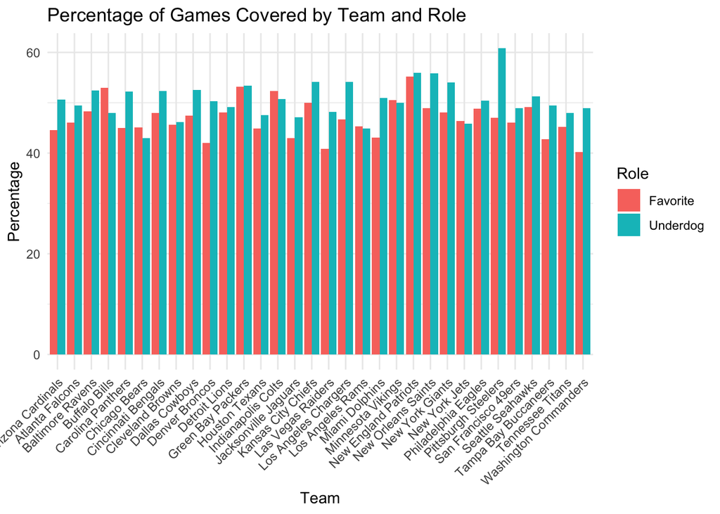

```r
# Plot the data in a dual barplot for each team
ggplot(cover_percentages, aes(x = Team, y = Covered, fill = Role)) +
  geom_bar(stat = 'identity', position = 'dodge') +
  labs(title = 'Percentage of Games Covered by Team and Role',
       x = 'Team',
       y = 'Percentage') +
  theme_minimal() +
  theme(axis.text.x = element_text(angle = 45, hjust = 1))
```

[figure not shown]

```r
library(ggwordcloud)

# Obtain the number of times each team has played in the playoffs
top_playoffs <- all_games_df |>
  filter(Playoff_Game == "1") |>
  group_by(Favorite) |>
  summarize(term_frequency = n()) |>
  arrange(desc(term_frequency))

# Create a word cloud of the top playoff teams
top_playoffs |>
  ggplot() +
  geom_text_wordcloud_area(aes(label = Favorite,
                           size = term_frequency)) +
  scale_size_area(max_size = 50) +
  theme_bw()
```

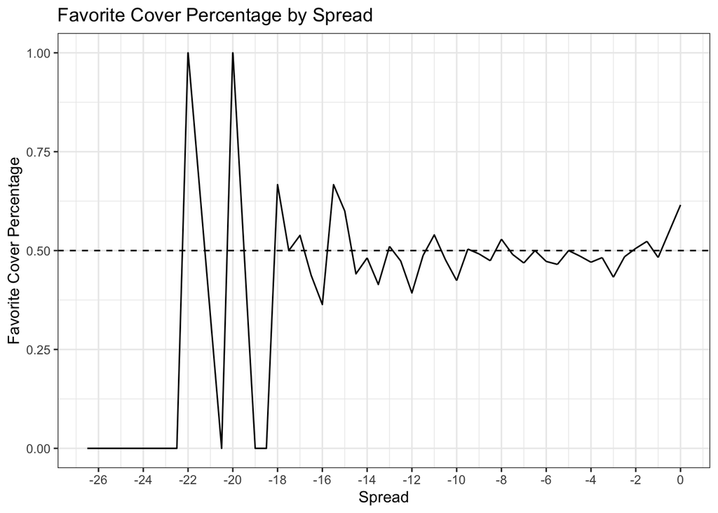

```r
library(ggplot2)

# Lets make a column called Favorite_Cover_Percentage by grouping the spread
Favorite_Cover_Percentage <- all_games_df |>
  group_by(Spread_Value) |>
  mutate(Favorite_Cover = if_else(Favorite_Cover == "Covered", 1, 0)) |>
  mutate(Favorite_Cover_Percentage = sum(Favorite_Cover) / n())

# Create a line plot with the y-axis being percentage the favorite team covers and the x-axis the spread of the game
Favorite_Cover_Percentage |>
  ggplot(aes(x = Spread_Value, y = Favorite_Cover_Percentage)) +
  geom_line() +
  labs(title = "Favorite Cover Percentage by Spread",
       x = "Spread",
       y = "Favorite Cover Percentage") +
  geom_hline(yintercept = 0.5, linetype = "dashed") +
  scale_x_continuous(breaks = seq(-30, 0, 2)) +
  theme_bw()
```

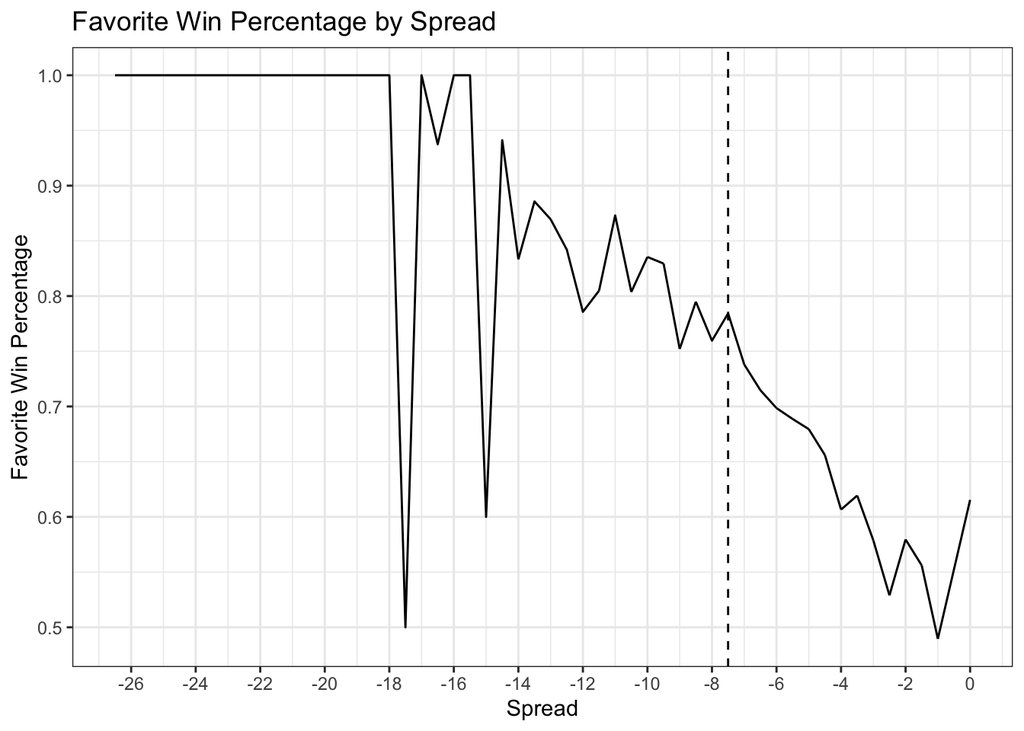

```r
# Lets make a column called Favorite_Win_Percentage by grouping the spread
Favorite_Win_Percentage <- all_games_df |>
  group_by(Spread_Value) |>
  filter(Result != "T") |>
  mutate(Favorite_Win = if_else(Result == "W", 1, 0)) |>
  mutate(Favorite_Win_Percentage = sum(Favorite_Win) / n())

# Create a line plot with the y-axis being percentage the favorite team wins and the x-axis the spread of the game
Favorite_Win_Percentage |>
  ggplot(aes(x = Spread_Value, y = Favorite_Win_Percentage)) +
  geom_line() +
  labs(title = "Favorite Win Percentage by Spread",
       x = "Spread",
       y = "Favorite Win Percentage") +
  scale_x_continuous(breaks = seq(-30, 0, 2)) +
  geom_vline(xintercept = -7.5, linetype = "dashed") +
  theme_bw()
```

```r
library(ggplot2)

# Lets make a column called Favorite_Cover_Percentage by grouping the spread
Favorite_Cover_Percentage_Week <- all_games_df |>
    filter(str_detect(`Week/Round`, "Week")) |>
    group_by(Spread_Value) |>
    mutate(Favorite_Cover = if_else(Favorite_Cover == "Covered", 1, 0)) |>
    mutate(Favorite_Cover_Percentage = sum(Favorite_Cover) / n())

# Lets calculate the variance of the Favorite_Cover_Percentage per Week. Therefore it should be 18 variances for 18 weeks. Make a new dataset called Variance_By_Week
Variance_By_Week <- Favorite_Cover_Percentage_Week |>
    group_by(`Week/Round`) |>
    summarize(variance = var(Favorite_Cover_Percentage)) |>
    mutate(`Week/Round` = str_remove(`Week/Round`, "Week_")) |>
    mutate(`Week/Round` = as.numeric(`Week/Round`)) |>
    arrange(`Week/Round`)

Variance_By_Week
```

```
# A tibble: 18 × 2
   `Week/Round` variance
          <dbl>    <dbl>
 1            1 0.000976
 2            2 0.00117
 3            3 0.00333
 4            4 0.00169
 5            5 0.00165
 6            6 0.00212
 7            7 0.00126
 8            8 0.00208
 9            9 0.00134
10           10 0.000953
11           11 0.00134
12           12 0.00189
13           13 0.00266
14           14 0.00122
15           15 0.00188
16           16 0.00203
17           17 0.00134
18           18 0.00165
```

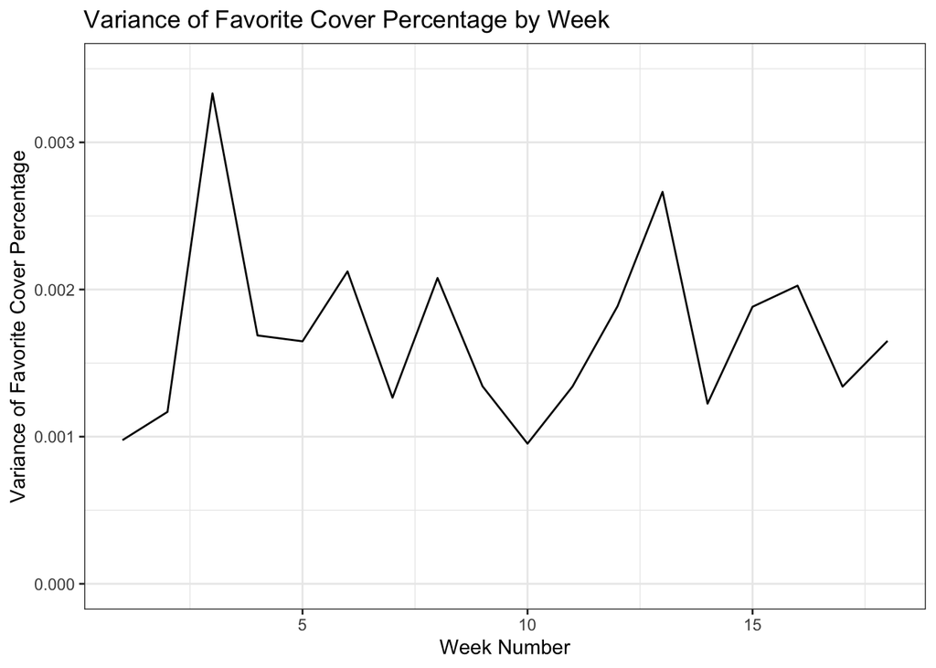

```r
# Create a line plot with the y-axis being variance of the percentage the favorite team covers and the x-axis the week of the game
Variance_By_Week |>
    ggplot(aes(x = `Week/Round`, y = variance, group = 1)) +
    geom_line() +
    labs(title = "Variance of Favorite Cover Percentage by Week",
         x = "Week Number",
         y = "Variance of Favorite Cover Percentage") +
    scale_y_continuous(limits = c(0, 0.0035)) +
    theme_bw()
```

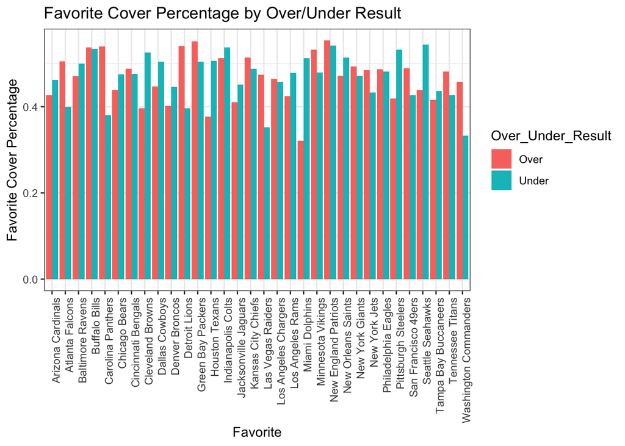

```r
library(ggplot2)

Over_Hit_Spread_Cover <- all_games_df |>
    filter(Over_Under_Result != "Push") |>
    group_by(Favorite, Over_Under_Result) |>
    mutate(Favorite_Cover = if_else(Favorite_Cover == "Covered", 1, 0)) |>
    mutate(Favorite_Cover_Percentage = sum(Favorite_Cover) / n()) |>
    select(Over_Under_Result, Favorite_Cover_Percentage, Favorite)

# Make a bar plot of the percentage the favorite team covers the spread by the Favorite team, there should be two bars per team, one for the Over and one for the Under
Over_Hit_Spread_Cover |>
    ggplot(aes(x = Favorite, y = Favorite_Cover_Percentage, fill = Over_Under_Result)) +
    geom_bar(stat = "identity", position = "dodge") +
    labs(title = "Favorite Cover Percentage by Over/Under Result",
         x = "Favorite",
         y = "Favorite Cover Percentage") +
    theme_bw() +
theme(axis.text.x = element_text(angle = 90, hjust = 1))
```

# Modeling

Now that we have all of our data prepared, lets focus on the modeling aspect. For modelling, we will be predicting whethjer or not the favorite team will cover the spread. In order to do this, we cannot know the result of the game, the score of either team, total number of points scored by both team, or the over under result. Therefore, we will first be removing these columns from our dataset.

```r
all_games_df |>
    glimpse()
```

```
Rows: 5,917
Columns: 19
$ ...1              <dbl> 1, 2, 3, 4, 5, 6, 7, 8, 9, 10, 11, 12, 13, 14, 15, 1…
$ Day               <chr> "Sat", "Sat", "Sun", "Sun", "Sat", "Sat", "Sun", "Su…
$ Date              <date> 2003-01-04, 2003-01-04, 2003-01-05, 2003-01-05, 200…
$ `Time (ET)`       <dbl> 4, 8, 1, 4, 4, 8, 1, 4, 3, 6, 6, 4, 8, 1, 4, 4, 8, 1…
$ Favorite_Home     <chr> "H", "H", "H", "H", "H", "H", "H", "H", "H", "H", "N…
$ Favorite          <chr> "New York Jets", "Green Bay Packers", "Pittsburgh St…
$ Underdog          <chr> "Indianapolis Colts", "Atlanta Falcons", "Cleveland …
$ Season            <int> 2002, 2002, 2002, 2002, 2002, 2002, 2002, 2002, 2002…
$ `Week/Round`      <chr> "AFC Wild Card", "NFC Wild Card", "AFC Wild Card", "…
$ Result            <chr> "W", "L", "W", "W", "W", "W", "W", "W", "L", "W", "L…
$ Overtime          <dbl> 0, 0, 0, 0, 1, 0, 0, 0, 0, 0, 0, 0, 0, 1, 0, 0, 0, 0…
$ Favorite_Score    <int> 41, 7, 36, 39, 34, 20, 31, 30, 10, 41, 21, 20, 29, 3…
$ Underdog_Score    <int> 0, 27, 33, 38, 31, 6, 6, 10, 27, 24, 48, 17, 10, 27,…
$ Total_Points      <int> 41, 34, 69, 77, 65, 26, 37, 40, 37, 65, 69, 37, 39, …
$ Over_Under_Result <chr> "Under", "Under", "Over", "Over", "Over", "Under", "…
$ Betting_Line      <dbl> 42.0, 40.5, 41.0, 41.0, 44.0, 38.5, 39.5, 47.0, 33.5…
$ Favorite_Cover    <chr> "Covered", "Failed", "Failed", "Failed", "Failed", "…
$ Spread_Value      <dbl> -6.0, -6.5, -8.0, -3.0, -4.5, -7.5, -6.0, -5.5, -4.0…
$ Playoff_Game      <dbl> 1, 1, 1, 1, 1, 1, 1, 1, 1, 1, 1, 1, 1, 1, 1, 1, 1, 1…
```

```r
library(tidyverse)
library(tidymodels)
theme_set(theme_bw())
tidymodels_prefer()

df <- read_csv("/Users/giovanni-lunetta/uconn_masters/s2/stat_5125/Final Project/all_games_df.csv")
df <- df |>
    select(-c(...1, Date))

df_model <- df |>
    select(-c(Favorite_Score, Underdog_Score, Total_Points, Over_Under_Result, Result))

df_model <- df_model |>
  mutate(
    Day = as.character(Day),
    `Time (ET)` = as.numeric(`Time (ET)`),
    Favorite_Home = as.character(Favorite_Home),
    Favorite = as.character(Favorite),
    Underdog = as.character(Underdog),
    Season = as.numeric(Season),
    `Week/Round` = as.character(`Week/Round`),
    Overtime = as.numeric(Overtime),
    Betting_Line = as.numeric(Betting_Line),
    Favorite_Cover = as.character(Favorite_Cover),
    Spread_Value = as.numeric(Spread_Value),
    Playoff_Game = as.numeric(Playoff_Game)
  )

df_model <- df_model |>
  mutate(Favorite_Cover = ifelse(Favorite_Cover == "Push", "Failed", Favorite_Cover))

df_model |>
  glimpse()
```

```
Rows: 5,917
Columns: 12
$ Day            <chr> "Sat", "Sat", "Sun", "Sun", "Sat", "Sat", "Sun", "Sun",…
$ `Time (ET)`    <dbl> 4, 8, 1, 4, 4, 8, 1, 4, 3, 6, 6, 4, 8, 1, 4, 4, 8, 1, 4…
$ Favorite_Home  <chr> "H", "H", "H", "H", "H", "H", "H", "H", "H", "H", "N", …
$ Favorite       <chr> "New York Jets", "Green Bay Packers", "Pittsburgh Steel…
$ Underdog       <chr> "Indianapolis Colts", "Atlanta Falcons", "Cleveland Bro…
$ Season         <dbl> 2002, 2002, 2002, 2002, 2002, 2002, 2002, 2002, 2002, 2…
$ `Week/Round`   <chr> "AFC Wild Card", "NFC Wild Card", "AFC Wild Card", "NFC…
$ Overtime       <dbl> 0, 0, 0, 0, 1, 0, 0, 0, 0, 0, 0, 0, 0, 1, 0, 0, 0, 0, 1…
$ Betting_Line   <dbl> 42.0, 40.5, 41.0, 41.0, 44.0, 38.5, 39.5, 47.0, 33.5, 4…
$ Favorite_Cover <chr> "Covered", "Failed", "Failed", "Failed", "Failed", "Cov…
$ Spread_Value   <dbl> -6.0, -6.5, -8.0, -3.0, -4.5, -7.5, -6.0, -5.5, -4.0, -…
$ Playoff_Game   <dbl> 1, 1, 1, 1, 1, 1, 1, 1, 1, 1, 1, 1, 1, 1, 1, 1, 1, 1, 1…
```

As for the models, we will begin by splitting the data into training and testing sets. This is important as we want to train our models on a subset of the data and then test the models on a different subset of the data. This will allow us to see how well our models generalize to new data.

```r
set.seed(123)
data_split <- initial_split(df_model, prop = 0.7, strata = NULL)

training_set <- training(data_split)
testing_set <- testing(data_split)
```

Furthermore, we will also be splitting the training set into a training and validation set. This will allow us to tune and compare our models on the validation set. The method for obtaining the validation set that will be used is the bootstrap method.

```r
set.seed(123)
bootstrap_set <- bootstraps(training_set, times = 10)
```

These workflows are defined below.

```r
log_maxlikelihood <- logistic_reg() |>
  set_engine("glm") |>
  set_mode("classification")

recipe <- recipe(Favorite_Cover ~ ., data = training_set) |>
  step_normalize(all_numeric_predictors()) |>
  step_dummy(all_nominal_predictors(), -all_outcomes())

workflow_A <- workflow() |>
  add_model(log_maxlikelihood) |>
  add_recipe(recipe)
```

```r
log_lasso <- logistic_reg(penalty = 0.1) |>
  set_engine("glmnet") |>
  set_mode("classification")

workflow_B <- workflow() |>
  add_recipe(recipe) |>
  add_model(log_lasso)
```

```r
knn <- nearest_neighbor(neighbors = 10) |>
  set_mode("classification") |>
  set_engine("kknn")

workflow_C <- workflow() |>
  add_recipe(recipe) |>
  add_model(knn)
```

```r
library(ranger)
rfr <- rand_forest() |>
  set_mode("classification") |>
  set_engine("ranger")

workflow_D <- workflow() |>
  add_recipe(recipe) |>
  add_model(rfr)
```

Now that we have our workflows, we can create a workflow object for each model, making it easy to fit each model.

```r
# YOUR CODE HERE
workflow_names <- c("glm_logistic",
                    "glm_lasso",
                    "knn",
                    "rf")

workflow_objects <- list(workflow_A,
                         workflow_B,
                         workflow_C,
                         workflow_D)

workflows_tbl <- tibble(work_names = workflow_names,
                        work_objects = workflow_objects)
```

With the workflow object in place, we can fit our training set to each of the models.

```r
set.seed(123)
workflows_tbl <-  workflows_tbl |>
  rowwise() |>
  mutate(fits = list(fit(work_objects,
                         training_set)))
```

```r
metric_set <- metric_set(roc_auc)
```

```r
workflows_bootstrap <- workflows_tbl |>
  mutate(fits = list(fit_resamples(work_objects,
                                   bootstrap_set,
                                   metrics = metric_set))) |>
  mutate(metrics = list(collect_metrics(fits)))
```

```
→ A | warning: prediction from a rank-deficient fit may be misleading
```

```
There were issues with some computations   A: x1
```

```
There were issues with some computations   A: x3
```

```
There were issues with some computations   A: x10
```

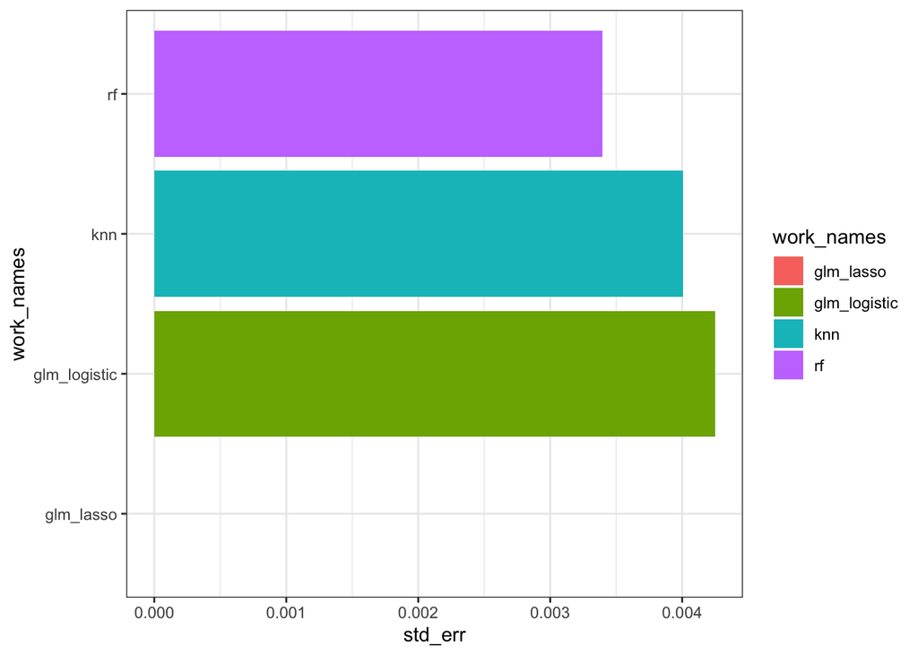

```r
# YOUR CODE HERE
workflows_bootstrap |>
  select(c(work_names,
           metrics)) |>
  unnest(metrics) |>
  ggplot(aes(y = work_names,
             fill = work_names,
             x = std_err)) +
  geom_col()
```